# Exam Preparation

### Numerical continuous variables

The code in this section is already prepared, we will run through the code chunks together.

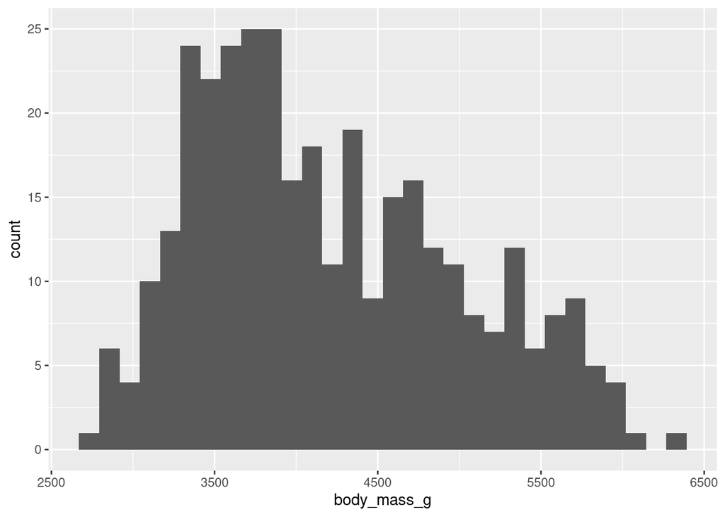

```r
ggplot(data = penguins,
       mapping = aes(x = body_mass_g)) +
  geom_histogram()
```

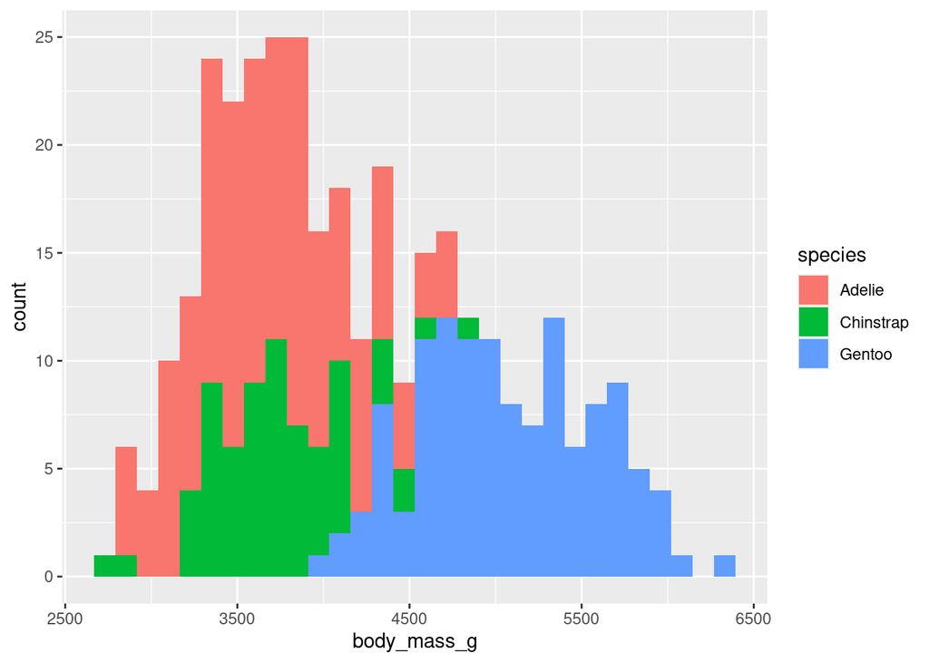

```r
ggplot(data = penguins,
       mapping = aes(x = body_mass_g,
                     fill = species)) +
  geom_histogram()
```

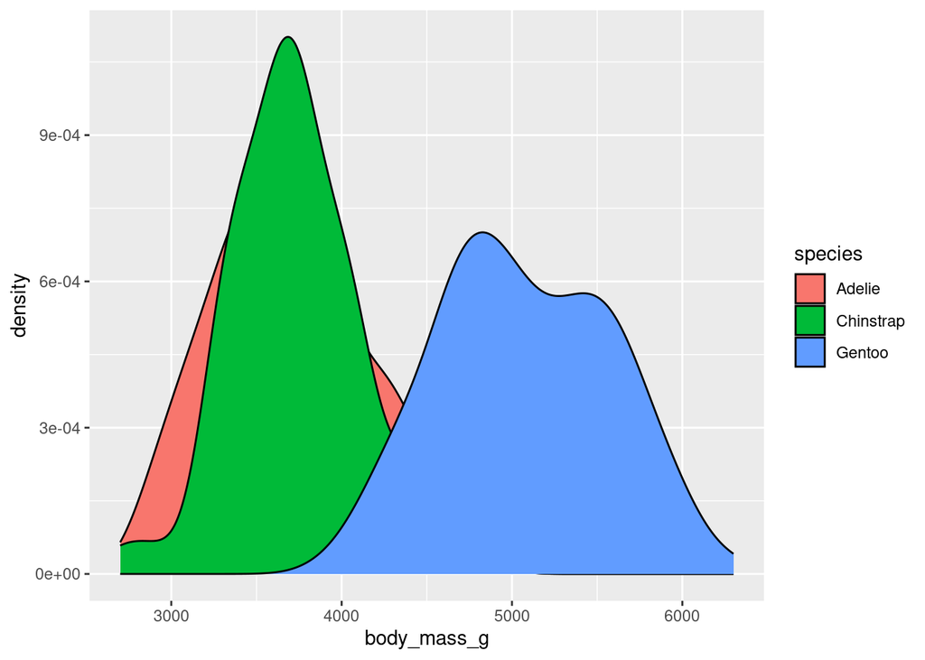

```r
ggplot(data = penguins,
       mapping = aes(x = body_mass_g,
                     fill = species)) +
  geom_density()
```

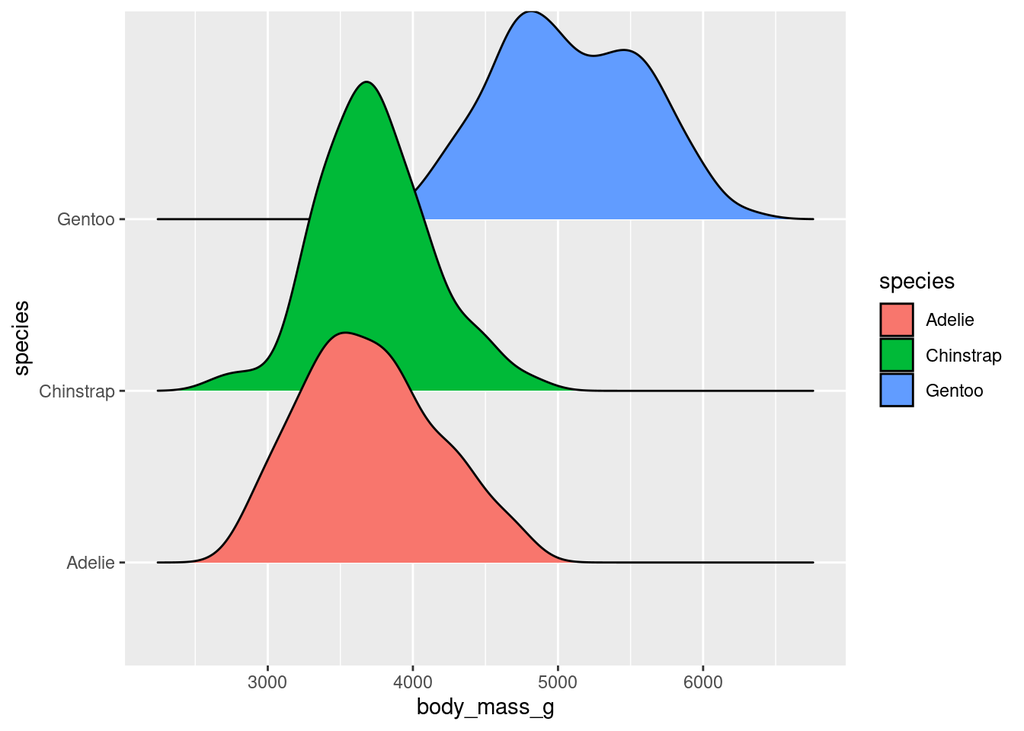

```r
ggplot(data = penguins,
       mapping = aes(x = body_mass_g,
                     y = species,
                     fill = species)) +
  geom_density_ridges()
```

# Module 02b: Working with R

## Import

```r
library(ggplot2)
library(dplyr)
library(gapminder)
```

## Explore

```r
head(gapminder)
```

```
# A tibble: 6 × 6
  country     continent  year lifeExp      pop gdpPercap
  <fct>       <fct>     <int>   <dbl>    <int>     <dbl>
1 Afghanistan Asia       1952    28.8  8425333      779.
2 Afghanistan Asia       1957    30.3  9240934      821.
3 Afghanistan Asia       1962    32.0 10267083      853.
4 Afghanistan Asia       1967    34.0 11537966      836.
5 Afghanistan Asia       1972    36.1 13079460      740.
6 Afghanistan Asia       1977    38.4 14880372      786.
```

```r
tail(gapminder)
```

```
# A tibble: 6 × 6
  country  continent  year lifeExp      pop gdpPercap
  <fct>    <fct>     <int>   <dbl>    <int>     <dbl>
1 Zimbabwe Africa     1982    60.4  7636524      789.
2 Zimbabwe Africa     1987    62.4  9216418      706.
3 Zimbabwe Africa     1992    60.4 10704340      693.
4 Zimbabwe Africa     1997    46.8 11404948      792.
5 Zimbabwe Africa     2002    40.0 11926563      672.
6 Zimbabwe Africa     2007    43.5 12311143      470.
```

```r
glimpse(gapminder)
```

```
Rows: 1,704
Columns: 6
$ country   <fct> "Afghanistan", "Afghanistan", "Afghanistan", "Afghanistan", …
$ continent <fct> Asia, Asia, Asia, Asia, Asia, Asia, Asia, Asia, Asia, Asia, …
$ year      <int> 1952, 1957, 1962, 1967, 1972, 1977, 1982, 1987, 1992, 1997, …
$ lifeExp   <dbl> 28.801, 30.332, 31.997, 34.020, 36.088, 38.438, 39.854, 40.8…
$ pop       <int> 8425333, 9240934, 10267083, 11537966, 13079460, 14880372, 12…
$ gdpPercap <dbl> 779.4453, 820.8530, 853.1007, 836.1971, 739.9811, 786.1134, …
```

```r
str(gapminder)
```

```
tibble [1,704 × 6] (S3: tbl_df/tbl/data.frame)
 $ country  : Factor w/ 142 levels "Afghanistan",..: 1 1 1 1 1 1 1 1 1 1 ...
 $ continent: Factor w/ 5 levels "Africa","Americas",..: 3 3 3 3 3 3 3 3 3 3 ...
 $ year     : int [1:1704] 1952 1957 1962 1967 1972 1977 1982 1987 1992 1997 ...
 $ lifeExp  : num [1:1704] 28.8 30.3 32 34 36.1 ...
 $ pop      : int [1:1704] 8425333 9240934 10267083 11537966 13079460 14880372 12881816 13867957 16317921 22227415 ...
 $ gdpPercap: num [1:1704] 779 821 853 836 740 ...
```

```r
nrow(gapminder)
```

```
[1] 1704
```

```r
ncol(gapminder)
```

```
[1] 6
```

## Transform - Narrow down

```r
gapminder_2007 <- gapminder |>
  filter(year == 2007)
```

- Keyboard shortcut for pipe operator: Ctrl / Cmd + Shift + M
- Keyboard shortcut for assignment operator: Alt + -

## Visualize

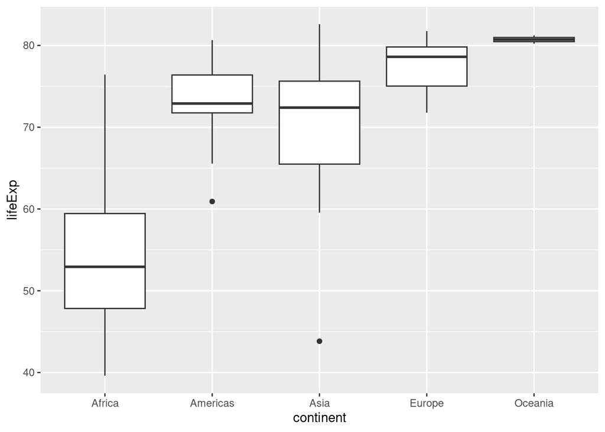

```r
ggplot(data = gapminder_2007,
       mapping = aes(x = continent,
                     y = lifeExp)) +
  geom_boxplot()
```

# Module 02: Make a plot

## Task 1: Import

The required packages for this homework exercise have already been added.

1. Run the code chunk with the label ‘load-packages’ to load the required packages. Tipp: Click on the green play button in the top right corner of the code chunk.

```r
library(gapminder)
library(ggplot2)
library(dplyr)
```

## Task 2: Transform for data in 2007

Below is a typical task description as you will find them in the homework assignments. For “Fill in the gaps” tasks, you should replace the underscores ___ with the described code and then change the value of the code block option from false to true. In other tasks, you will create your own code from scratch. Over time, the task descriptions will be become less detailed.

**Fill in the gaps**

1. A code chunk has already been created below.
2. Start with the `gapminder` object and add the pipe operator at the end of the line.
3. On a new line use the `filter()` function to narrow down the data for observation of the year 2007.
4. Use the assignment operator to assign the data to an object named `gapminder_2007`.
5. Run the code contained in the code chunk and fix any errors.
6. Next to the code chunk option `#| eval:` change the value from `false` to `true`.
7. Render the document and fix any errors.

```r
gapminder_2007 <- gapminder |>
  filter(year == 2007)
```

## Task 3: Create a boxplot

This is a typical task without any starter code.

1. Add a new code chunk below point 5.
2. Use the `ggplot()` function and the `gapminder_2007` object to create a boxplot with the following aesthetic mappings:
- continent to the x-axis;
- life expectancy to the y-axis;
- continent to color using the `fill = continent` argument inside `aes()`
3. Run the code contained in the code chunk and fix any errors.
4. What are the data types of the three variables used for aesthetic mappings?

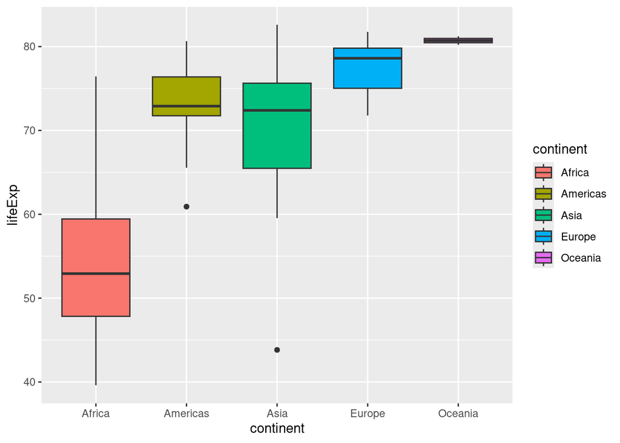

```r
ggplot(data = gapminder_2007,
       mapping = aes(x = continent,
                     y = lifeExp,
                     fill = continent)) +
  geom_boxplot()
```

# Module 03a: Data transformation with dplyr

```r
library(readr)
library(dplyr)
```

## Import

In this exercise we use data of the UNICEF/WHO Joint Monitoring Programme (JMP) for Water Supply, Sanitation and Hygiene (WASH). The data is available at https://washdata.org/data and published as an R data package at https://github.com/WASHNote/jmpwashdata/.

The data set is available in the `data` folder as a CSV file named `jmp_wld_sanitation_long.csv`.

The data set contains the following variables:

- `name`: country name
- `iso3`: ISO3 country code
- `year`: year of observation
- `region_sdg`: SDG region
- `residence`: residence type (national, rural, urban)
- `varname_short`: short variable name (JMP naming convention)
- `varname_long`: long variable name (JMP naming convention)

We use the `read_csv()` function to import the data set into R.

```r
sanitation <- read_csv("data/jmp_wld_sanitation_long.csv")
```

## Explore

```r
sanitation
```

```
# A tibble: 73,710 × 8
   name      iso3   year region_sdg varname_short varname_long residence percent
   <chr>     <chr> <dbl> <chr>      <chr>         <chr>        <chr>       <dbl>
 1 Afghanis… AFG    2000 Central a… san_bas       basic sanit… national    21.9
 2 Afghanis… AFG    2000 Central a… san_bas       basic sanit… rural       19.3
 3 Afghanis… AFG    2000 Central a… san_bas       basic sanit… urban       30.9
 4 Afghanis… AFG    2000 Central a… san_lim       limited san… national     5.65
 5 Afghanis… AFG    2000 Central a… san_lim       limited san… rural        3.14
 6 Afghanis… AFG    2000 Central a… san_lim       limited san… urban       14.5
 7 Afghanis… AFG    2000 Central a… san_unimp     unimproved … national    46.7
 8 Afghanis… AFG    2000 Central a… san_unimp     unimproved … rural       46.3
 9 Afghanis… AFG    2000 Central a… san_unimp     unimproved … urban       48.1
10 Afghanis… AFG    2000 Central a… san_od        no sanitati… national    25.8
# ℹ 73,700 more rows
```

```r
glimpse(sanitation)
```

```
Rows: 73,710
Columns: 8
$ name          <chr> "Afghanistan", "Afghanistan", "Afghanistan", "Afghanista…
$ iso3          <chr> "AFG", "AFG", "AFG", "AFG", "AFG", "AFG", "AFG", "AFG", …
$ year          <dbl> 2000, 2000, 2000, 2000, 2000, 2000, 2000, 2000, 2000, 20…
$ region_sdg    <chr> "Central and Southern Asia", "Central and Southern Asia"…
$ varname_short <chr> "san_bas", "san_bas", "san_bas", "san_lim", "san_lim", "…
$ varname_long  <chr> "basic sanitation services", "basic sanitation services"…
$ residence     <chr> "national", "rural", "urban", "national", "rural", "urba…
$ percent       <dbl> 21.870802, 19.322798, 30.863719, 5.648528, 3.136148, 14.…
```

## Transform with dplyr

The `dplyr` R Package aims to provide a function for each basic verb of data manipulation. These verbs can be organised into three categories based on the component of the dataset that they work with:

- Rows
- Columns
- Groups of rows

### filter()

The function `filter()` chooses rows based on column values. To use filtering effectively, you have to know how to select the observations that you want using the comparison operators. R provides the standard suite: >, >=, <, <=, != (not equal), and == (equal).

```r
sanitation |>
  filter(residence == "national")
```

```
# A tibble: 24,570 × 8
   name      iso3   year region_sdg varname_short varname_long residence percent
   <chr>     <chr> <dbl> <chr>      <chr>         <chr>        <chr>       <dbl>
 1 Afghanis… AFG    2000 Central a… san_bas       basic sanit… national    21.9
 2 Afghanis… AFG    2000 Central a… san_lim       limited san… national     5.65
 3 Afghanis… AFG    2000 Central a… san_unimp     unimproved … national    46.7
 4 Afghanis… AFG    2000 Central a… san_od        no sanitati… national    25.8
 5 Afghanis… AFG    2000 Central a… san_sm        safely mana… national    NA
 6 Afghanis… AFG    2001 Central a… san_bas       basic sanit… national    21.9
 7 Afghanis… AFG    2001 Central a… san_lim       limited san… national     5.66
 8 Afghanis… AFG    2001 Central a… san_unimp     unimproved … national    46.7
 9 Afghanis… AFG    2001 Central a… san_od        no sanitati… national    25.8
10 Afghanis… AFG    2001 Central a… san_sm        safely mana… national    NA
# ℹ 24,560 more rows
```

```r
sanitation |>
  filter(residence != "national")
```

```
# A tibble: 49,140 × 8
   name      iso3   year region_sdg varname_short varname_long residence percent
   <chr>     <chr> <dbl> <chr>      <chr>         <chr>        <chr>       <dbl>
 1 Afghanis… AFG    2000 Central a… san_bas       basic sanit… rural       19.3
 2 Afghanis… AFG    2000 Central a… san_bas       basic sanit… urban       30.9
 3 Afghanis… AFG    2000 Central a… san_lim       limited san… rural        3.14
 4 Afghanis… AFG    2000 Central a… san_lim       limited san… urban       14.5
 5 Afghanis… AFG    2000 Central a… san_unimp     unimproved … rural       46.3
 6 Afghanis… AFG    2000 Central a… san_unimp     unimproved … urban       48.1
 7 Afghanis… AFG    2000 Central a… san_od        no sanitati… rural       31.3
 8 Afghanis… AFG    2000 Central a… san_od        no sanitati… urban        6.51
 9 Afghanis… AFG    2000 Central a… san_sm        safely mana… rural       NA
10 Afghanis… AFG    2000 Central a… san_sm        safely mana… urban       NA
# ℹ 49,130 more rows
```

```r
sanitation |>
  filter(residence == "national", iso3 == "SEN")
```

```
# A tibble: 105 × 8
   name    iso3   year region_sdg   varname_short varname_long residence percent
   <chr>   <chr> <dbl> <chr>        <chr>         <chr>        <chr>       <dbl>
 1 Senegal SEN    2000 Sub-Saharan… san_bas       basic sanit… national     37.5
 2 Senegal SEN    2000 Sub-Saharan… san_lim       limited san… national     10.8
 3 Senegal SEN    2000 Sub-Saharan… san_unimp     unimproved … national     27.4
 4 Senegal SEN    2000 Sub-Saharan… san_od        no sanitati… national     24.4
 5 Senegal SEN    2000 Sub-Saharan… san_sm        safely mana… national     14.0
 6 Senegal SEN    2001 Sub-Saharan… san_bas       basic sanit… national     38.4
 7 Senegal SEN    2001 Sub-Saharan… san_lim       limited san… national     11.0
 8 Senegal SEN    2001 Sub-Saharan… san_unimp     unimproved … national     26.8
 9 Senegal SEN    2001 Sub-Saharan… san_od        no sanitati… national     23.7
10 Senegal SEN    2001 Sub-Saharan… san_sm        safely mana… national     14.3
# ℹ 95 more rows
```

```r
sanitation |>
  filter(iso3 == "UGA" | iso3 == "PER" | iso3 == "IND")
```

```
# A tibble: 945 × 8
   name  iso3   year region_sdg     varname_short varname_long residence percent
   <chr> <chr> <dbl> <chr>          <chr>         <chr>        <chr>       <dbl>
 1 India IND    2000 Central and S… san_bas       basic sanit… national   15.0
 2 India IND    2000 Central and S… san_bas       basic sanit… rural       2.25
 3 India IND    2000 Central and S… san_bas       basic sanit… urban      48.4
 4 India IND    2000 Central and S… san_lim       limited san… national    5.15
 5 India IND    2000 Central and S… san_lim       limited san… rural       0.515
 6 India IND    2000 Central and S… san_lim       limited san… urban      17.3
 7 India IND    2000 Central and S… san_unimp     unimproved … national    5.73
 8 India IND    2000 Central and S… san_unimp     unimproved … rural       5.00
 9 India IND    2000 Central and S… san_unimp     unimproved … urban       7.65
10 India IND    2000 Central and S… san_od        no sanitati… national   74.1
# ℹ 935 more rows
```

```r
sanitation |>
  filter(iso3 %in% c("UGA", "PER", "IND"))
```

```
# A tibble: 945 × 8
   name  iso3   year region_sdg     varname_short varname_long residence percent
   <chr> <chr> <dbl> <chr>          <chr>         <chr>        <chr>       <dbl>
 1 India IND    2000 Central and S… san_bas       basic sanit… national   15.0
 2 India IND    2000 Central and S… san_bas       basic sanit… rural       2.25
 3 India IND    2000 Central and S… san_bas       basic sanit… urban      48.4
 4 India IND    2000 Central and S… san_lim       limited san… national    5.15
 5 India IND    2000 Central and S… san_lim       limited san… rural       0.515
 6 India IND    2000 Central and S… san_lim       limited san… urban      17.3
 7 India IND    2000 Central and S… san_unimp     unimproved … national    5.73
 8 India IND    2000 Central and S… san_unimp     unimproved … rural       5.00
 9 India IND    2000 Central and S… san_unimp     unimproved … urban       7.65
10 India IND    2000 Central and S… san_od        no sanitati… national   74.1
# ℹ 935 more rows
```

```r
sanitation |>
  filter(percent > 80)
```

```
# A tibble: 8,314 × 8
   name    iso3   year region_sdg   varname_short varname_long residence percent
   <chr>   <chr> <dbl> <chr>        <chr>         <chr>        <chr>       <dbl>
 1 Albania ALB    2000 Northern Am… san_bas       basic sanit… national     89.5
 2 Albania ALB    2000 Northern Am… san_bas       basic sanit… rural        84.2
 3 Albania ALB    2000 Northern Am… san_bas       basic sanit… urban        96.9
 4 Albania ALB    2001 Northern Am… san_bas       basic sanit… national     90.0
 5 Albania ALB    2001 Northern Am… san_bas       basic sanit… rural        84.9
 6 Albania ALB    2001 Northern Am… san_bas       basic sanit… urban        97.0
 7 Albania ALB    2002 Northern Am… san_bas       basic sanit… national     90.6
 8 Albania ALB    2002 Northern Am… san_bas       basic sanit… rural        85.7
 9 Albania ALB    2002 Northern Am… san_bas       basic sanit… urban        97.0
10 Albania ALB    2003 Northern Am… san_bas       basic sanit… national     91.2
# ℹ 8,304 more rows
```

```r
sanitation |>
  filter(percent <= 5)
```

```
# A tibble: 21,424 × 8
   name      iso3   year region_sdg varname_short varname_long residence percent
   <chr>     <chr> <dbl> <chr>      <chr>         <chr>        <chr>       <dbl>
 1 Afghanis… AFG    2000 Central a… san_lim       limited san… rural        3.14
 2 Afghanis… AFG    2001 Central a… san_lim       limited san… rural        3.14
 3 Afghanis… AFG    2002 Central a… san_lim       limited san… rural        3.35
 4 Afghanis… AFG    2003 Central a… san_lim       limited san… rural        3.57
 5 Afghanis… AFG    2004 Central a… san_lim       limited san… rural        3.79
 6 Afghanis… AFG    2005 Central a… san_lim       limited san… rural        4.01
 7 Afghanis… AFG    2005 Central a… san_od        no sanitati… urban        4.86
 8 Afghanis… AFG    2006 Central a… san_lim       limited san… rural        4.22
 9 Afghanis… AFG    2006 Central a… san_od        no sanitati… urban        4.45
10 Afghanis… AFG    2007 Central a… san_lim       limited san… rural        4.44
# ℹ 21,414 more rows
```

```r
sanitation |>
  filter(is.na(percent))
```

```
# A tibble: 19,743 × 8
   name      iso3   year region_sdg varname_short varname_long residence percent
   <chr>     <chr> <dbl> <chr>      <chr>         <chr>        <chr>       <dbl>
 1 Afghanis… AFG    2000 Central a… san_sm        safely mana… national       NA
 2 Afghanis… AFG    2000 Central a… san_sm        safely mana… rural          NA
 3 Afghanis… AFG    2000 Central a… san_sm        safely mana… urban          NA
 4 Afghanis… AFG    2001 Central a… san_sm        safely mana… national       NA
 5 Afghanis… AFG    2001 Central a… san_sm        safely mana… rural          NA
 6 Afghanis… AFG    2001 Central a… san_sm        safely mana… urban          NA
 7 Afghanis… AFG    2002 Central a… san_sm        safely mana… national       NA
 8 Afghanis… AFG    2002 Central a… san_sm        safely mana… rural          NA
 9 Afghanis… AFG    2002 Central a… san_sm        safely mana… urban          NA
10 Afghanis… AFG    2003 Central a… san_sm        safely mana… national       NA
# ℹ 19,733 more rows
```

```r
sanitation |>
  filter(!is.na(percent))
```

```
# A tibble: 53,967 × 8
   name      iso3   year region_sdg varname_short varname_long residence percent
   <chr>     <chr> <dbl> <chr>      <chr>         <chr>        <chr>       <dbl>
 1 Afghanis… AFG    2000 Central a… san_bas       basic sanit… national    21.9
 2 Afghanis… AFG    2000 Central a… san_bas       basic sanit… rural       19.3
 3 Afghanis… AFG    2000 Central a… san_bas       basic sanit… urban       30.9
 4 Afghanis… AFG    2000 Central a… san_lim       limited san… national     5.65
 5 Afghanis… AFG    2000 Central a… san_lim       limited san… rural        3.14
 6 Afghanis… AFG    2000 Central a… san_lim       limited san… urban       14.5
 7 Afghanis… AFG    2000 Central a… san_unimp     unimproved … national    46.7
 8 Afghanis… AFG    2000 Central a… san_unimp     unimproved … rural       46.3
 9 Afghanis… AFG    2000 Central a… san_unimp     unimproved … urban       48.1
10 Afghanis… AFG    2000 Central a… san_od        no sanitati… national    25.8
# ℹ 53,957 more rows
```

- Keyboard shortcut for vertical bar | (OR) in US/CH is: Shift + / (Windows) and Option + / (Mac)
- Keyboard shortcut for vertical bar | (OR) in UK: It’s complitcated
- Keyboard shortcut for pipe operator: Ctrl / Cmd + Shift + M
- Keyboard shortcut for assignment operator: Alt + -

**Storing a resulting data frame as a new object**

```r
sanitation_national_2020_sm <- sanitation |>
  filter(residence == "national",
         year == 2020,
         varname_short == "san_sm")
```

### arrange()

The function `arrange()` changes the order of the rows.

```r
sanitation_national_2020_sm |>
  arrange(percent)
```

```
# A tibble: 234 × 8
   name      iso3   year region_sdg varname_short varname_long residence percent
   <chr>     <chr> <dbl> <chr>      <chr>         <chr>        <chr>       <dbl>
 1 Ethiopia  ETH    2020 Sub-Sahar… san_sm        safely mana… national     6.68
 2 Togo      TGO    2020 Sub-Sahar… san_sm        safely mana… national     9.13
 3 Chad      TCD    2020 Sub-Sahar… san_sm        safely mana… national    10.1
 4 Madagasc… MDG    2020 Sub-Sahar… san_sm        safely mana… national    10.4
 5 Guinea-B… GNB    2020 Sub-Sahar… san_sm        safely mana… national    12.2
 6 North Ma… MKD    2020 Northern … san_sm        safely mana… national    12.2
 7 Democrat… COD    2020 Sub-Sahar… san_sm        safely mana… national    12.7
 8 Ghana     GHA    2020 Sub-Sahar… san_sm        safely mana… national    13.3
 9 Central … CAF    2020 Sub-Sahar… san_sm        safely mana… national    13.6
10 Sierra L… SLE    2020 Sub-Sahar… san_sm        safely mana… national    14.0
# ℹ 224 more rows
```

```r
sanitation_national_2020_sm |>
  arrange(desc(percent))
```

```
# A tibble: 234 × 8
   name      iso3   year region_sdg varname_short varname_long residence percent
   <chr>     <chr> <dbl> <chr>      <chr>         <chr>        <chr>       <dbl>
 1 Andorra   AND    2020 Northern … san_sm        safely mana… national    100.
 2 Kuwait    KWT    2020 Western A… san_sm        safely mana… national    100
 3 Monaco    MCO    2020 Northern … san_sm        safely mana… national    100
 4 Singapore SGP    2020 Eastern a… san_sm        safely mana… national    100
 5 Republic… KOR    2020 Eastern a… san_sm        safely mana… national     99.9
 6 Switzerl… CHE    2020 Northern … san_sm        safely mana… national     99.7
 7 Austria   AUT    2020 Northern … san_sm        safely mana… national     99.6
 8 United A… ARE    2020 Western A… san_sm        safely mana… national     99.2
 9 Liechten… LIE    2020 Northern … san_sm        safely mana… national     98.8
10 United S… USA    2020 Northern … san_sm        safely mana… national     98.3
# ℹ 224 more rows
```

### select()

The `select()` function chooses columns based on their names.

```r
sanitation_national_2020_sm |>
  select(name, percent)
```

```
# A tibble: 234 × 2
   name                percent
   <chr>                 <dbl>
 1 Afghanistan            NA
 2 Albania                47.7
 3 Algeria                17.6
 4 American Samoa         NA
 5 Andorra               100.
 6 Angola                 NA
 7 Anguilla               NA
 8 Antigua and Barbuda    NA
 9 Argentina              NA
10 Armenia                69.3
# ℹ 224 more rows
```

```r
sanitation_national_2020_sm |>
  select(-varname_short)
```

```
# A tibble: 234 × 7
   name                iso3   year region_sdg     varname_long residence percent
   <chr>               <chr> <dbl> <chr>          <chr>        <chr>       <dbl>
 1 Afghanistan         AFG    2020 Central and S… safely mana… national     NA
 2 Albania             ALB    2020 Northern Amer… safely mana… national     47.7
 3 Algeria             DZA    2020 Western Asia … safely mana… national     17.6
 4 American Samoa      ASM    2020 Oceania        safely mana… national     NA
 5 Andorra             AND    2020 Northern Amer… safely mana… national    100.
 6 Angola              AGO    2020 Sub-Saharan A… safely mana… national     NA
 7 Anguilla            AIA    2020 Latin America… safely mana… national     NA
 8 Antigua and Barbuda ATG    2020 Latin America… safely mana… national     NA
 9 Argentina           ARG    2020 Latin America… safely mana… national     NA
10 Armenia             ARM    2020 Western Asia … safely mana… national     69.3
# ℹ 224 more rows
```

```r
sanitation_national_2020_sm |>
  select(name:region_sdg, percent)
```

```
# A tibble: 234 × 5
   name                iso3   year region_sdg                       percent
   <chr>               <chr> <dbl> <chr>                              <dbl>
 1 Afghanistan         AFG    2020 Central and Southern Asia           NA
 2 Albania             ALB    2020 Northern America and Europe         47.7
 3 Algeria             DZA    2020 Western Asia and Northern Africa    17.6
 4 American Samoa      ASM    2020 Oceania                             NA
 5 Andorra             AND    2020 Northern America and Europe        100.
 6 Angola              AGO    2020 Sub-Saharan Africa                  NA
 7 Anguilla            AIA    2020 Latin America and the Caribbean     NA
 8 Antigua and Barbuda ATG    2020 Latin America and the Caribbean     NA
 9 Argentina           ARG    2020 Latin America and the Caribbean     NA
10 Armenia             ARM    2020 Western Asia and Northern Africa    69.3
# ℹ 224 more rows
```

### rename()

The `rename()` function changes the names of variables.

```r
sanitation |>
  rename(country = name)
```

```
# A tibble: 73,710 × 8
   country   iso3   year region_sdg varname_short varname_long residence percent
   <chr>     <chr> <dbl> <chr>      <chr>         <chr>        <chr>       <dbl>
 1 Afghanis… AFG    2000 Central a… san_bas       basic sanit… national    21.9
 2 Afghanis… AFG    2000 Central a… san_bas       basic sanit… rural       19.3
 3 Afghanis… AFG    2000 Central a… san_bas       basic sanit… urban       30.9
 4 Afghanis… AFG    2000 Central a… san_lim       limited san… national     5.65
 5 Afghanis… AFG    2000 Central a… san_lim       limited san… rural        3.14
 6 Afghanis… AFG    2000 Central a… san_lim       limited san… urban       14.5
 7 Afghanis… AFG    2000 Central a… san_unimp     unimproved … national    46.7
 8 Afghanis… AFG    2000 Central a… san_unimp     unimproved … rural       46.3
 9 Afghanis… AFG    2000 Central a… san_unimp     unimproved … urban       48.1
10 Afghanis… AFG    2000 Central a… san_od        no sanitati… national    25.8
# ℹ 73,700 more rows
```

### mutate()

The `mutate()` function adds new variables based on existing variables or external data.

```r
sanitation |>
  mutate(prop = percent / 100)
```

```
# A tibble: 73,710 × 9
   name      iso3   year region_sdg varname_short varname_long residence percent
   <chr>     <chr> <dbl> <chr>      <chr>         <chr>        <chr>       <dbl>
 1 Afghanis… AFG    2000 Central a… san_bas       basic sanit… national    21.9
 2 Afghanis… AFG    2000 Central a… san_bas       basic sanit… rural       19.3
 3 Afghanis… AFG    2000 Central a… san_bas       basic sanit… urban       30.9
 4 Afghanis… AFG    2000 Central a… san_lim       limited san… national     5.65
 5 Afghanis… AFG    2000 Central a… san_lim       limited san… rural        3.14
 6 Afghanis… AFG    2000 Central a… san_lim       limited san… urban       14.5
 7 Afghanis… AFG    2000 Central a… san_unimp     unimproved … national    46.7
 8 Afghanis… AFG    2000 Central a… san_unimp     unimproved … rural       46.3
 9 Afghanis… AFG    2000 Central a… san_unimp     unimproved … urban       48.1
10 Afghanis… AFG    2000 Central a… san_od        no sanitati… national    25.8
# ℹ 73,700 more rows
# ℹ 1 more variable: prop <dbl>
```

```r
sanitation |>
  mutate(id = seq(1:n()))
```

```
# A tibble: 73,710 × 9
   name      iso3   year region_sdg varname_short varname_long residence percent
   <chr>     <chr> <dbl> <chr>      <chr>         <chr>        <chr>       <dbl>
 1 Afghanis… AFG    2000 Central a… san_bas       basic sanit… national    21.9
 2 Afghanis… AFG    2000 Central a… san_bas       basic sanit… rural       19.3
 3 Afghanis… AFG    2000 Central a… san_bas       basic sanit… urban       30.9
 4 Afghanis… AFG    2000 Central a… san_lim       limited san… national     5.65
 5 Afghanis… AFG    2000 Central a… san_lim       limited san… rural        3.14
 6 Afghanis… AFG    2000 Central a… san_lim       limited san… urban       14.5
 7 Afghanis… AFG    2000 Central a… san_unimp     unimproved … national    46.7
 8 Afghanis… AFG    2000 Central a… san_unimp     unimproved … rural       46.3
 9 Afghanis… AFG    2000 Central a… san_unimp     unimproved … urban       48.1
10 Afghanis… AFG    2000 Central a… san_od        no sanitati… national    25.8
# ℹ 73,700 more rows
# ℹ 1 more variable: id <int>
```

### relocate()

```r
sanitation |>
  mutate(id = 1:n()) |>
  relocate(id)
```

```
# A tibble: 73,710 × 9
      id name        iso3   year region_sdg varname_short varname_long residence
   <int> <chr>       <chr> <dbl> <chr>      <chr>         <chr>        <chr>
 1     1 Afghanistan AFG    2000 Central a… san_bas       basic sanit… national
 2     2 Afghanistan AFG    2000 Central a… san_bas       basic sanit… rural
 3     3 Afghanistan AFG    2000 Central a… san_bas       basic sanit… urban
 4     4 Afghanistan AFG    2000 Central a… san_lim       limited san… national
 5     5 Afghanistan AFG    2000 Central a… san_lim       limited san… rural
 6     6 Afghanistan AFG    2000 Central a… san_lim       limited san… urban
 7     7 Afghanistan AFG    2000 Central a… san_unimp     unimproved … national
 8     8 Afghanistan AFG    2000 Central a… san_unimp     unimproved … rural
 9     9 Afghanistan AFG    2000 Central a… san_unimp     unimproved … urban
10    10 Afghanistan AFG    2000 Central a… san_od        no sanitati… national
# ℹ 73,700 more rows
# ℹ 1 more variable: percent <dbl>
```

```r
sanitation |>
  mutate(id = 1:n()) |>
  relocate(id, .before = name)
```

```
# A tibble: 73,710 × 9
      id name        iso3   year region_sdg varname_short varname_long residence
   <int> <chr>       <chr> <dbl> <chr>      <chr>         <chr>        <chr>
 1     1 Afghanistan AFG    2000 Central a… san_bas       basic sanit… national
 2     2 Afghanistan AFG    2000 Central a… san_bas       basic sanit… rural
 3     3 Afghanistan AFG    2000 Central a… san_bas       basic sanit… urban
 4     4 Afghanistan AFG    2000 Central a… san_lim       limited san… national
 5     5 Afghanistan AFG    2000 Central a… san_lim       limited san… rural
 6     6 Afghanistan AFG    2000 Central a… san_lim       limited san… urban
 7     7 Afghanistan AFG    2000 Central a… san_unimp     unimproved … national
 8     8 Afghanistan AFG    2000 Central a… san_unimp     unimproved … rural
 9     9 Afghanistan AFG    2000 Central a… san_unimp     unimproved … urban
10    10 Afghanistan AFG    2000 Central a… san_od        no sanitati… national
# ℹ 73,700 more rows
# ℹ 1 more variable: percent <dbl>
```

### summarise()

The `summarise()` function reduces multiple values down to a single summary.

```r
sanitation_national_2020_sm |>
  summarise()
```

```
# A tibble: 1 × 0
```

```r
sanitation_national_2020_sm |>
  summarise(mean_percent = mean(percent))
```

```
# A tibble: 1 × 1
  mean_percent
         <dbl>
1           NA
```

```r
sanitation_national_2020_sm |>
  summarise(mean_percent = mean(percent, na.rm = TRUE))
```

```
# A tibble: 1 × 1
  mean_percent
         <dbl>
1         60.3
```

```r
sanitation_national_2020_sm |>
  summarise(n = n(),
            mean_percent = mean(percent, na.rm = TRUE))
```

```
# A tibble: 1 × 2
      n mean_percent
  <int>        <dbl>
1   234         60.3
```

```r
sanitation_national_2020_sm |>
  filter(!is.na(percent)) |>
  summarise(n = n(),
            mean_percent = mean(percent),
            sd_percent = sd(percent))
```

```
# A tibble: 1 × 3
      n mean_percent sd_percent
  <int>        <dbl>      <dbl>
1   120         60.3       29.9
```

### group_by()

The `group_by()` function is used to group the data by one or more variables.

```r
sanitation_national_2020_sm |>
  group_by(region_sdg)
```

```
# A tibble: 234 × 8
# Groups:   region_sdg [8]
   name      iso3   year region_sdg varname_short varname_long residence percent
   <chr>     <chr> <dbl> <chr>      <chr>         <chr>        <chr>       <dbl>
 1 Afghanis… AFG    2020 Central a… san_sm        safely mana… national     NA
 2 Albania   ALB    2020 Northern … san_sm        safely mana… national     47.7
 3 Algeria   DZA    2020 Western A… san_sm        safely mana… national     17.6
 4 American… ASM    2020 Oceania    san_sm        safely mana… national     NA
 5 Andorra   AND    2020 Northern … san_sm        safely mana… national    100.
 6 Angola    AGO    2020 Sub-Sahar… san_sm        safely mana… national     NA
 7 Anguilla  AIA    2020 Latin Ame… san_sm        safely mana… national     NA
 8 Antigua … ATG    2020 Latin Ame… san_sm        safely mana… national     NA
 9 Argentina ARG    2020 Latin Ame… san_sm        safely mana… national     NA
10 Armenia   ARM    2020 Western A… san_sm        safely mana… national     69.3
# ℹ 224 more rows
```

```r
sanitation_national_2020_sm |>
  group_by(region_sdg) |>
  summarise(n = n(),
            mean_percent = mean(percent),
            sd_percent = sd(percent))
```

```
# A tibble: 8 × 4
  region_sdg                           n mean_percent sd_percent
  <chr>                            <int>        <dbl>      <dbl>
1 Australia and New Zealand            2         78.2       5.61
2 Central and Southern Asia           14         NA        NA
3 Eastern and South-Eastern Asia      18         NA        NA
4 Latin America and the Caribbean     50         NA        NA
5 Northern America and Europe         53         NA        NA
6 Oceania                             21         NA        NA
7 Sub-Saharan Africa                  51         NA        NA
8 Western Asia and Northern Africa    25         NA        NA
```

```r
sanitation_national_2020_sm |>
  filter(!is.na(percent)) |>
  group_by(region_sdg) |>
  summarise(n = n(),
            mean_percent = mean(percent),
            sd_percent = sd(percent))
```

```
# A tibble: 8 × 4
  region_sdg                           n mean_percent sd_percent
  <chr>                            <int>        <dbl>      <dbl>
1 Australia and New Zealand            2         78.2       5.61
2 Central and Southern Asia            5         58.2      21.5
3 Eastern and South-Eastern Asia      11         69.8      21.4
4 Latin America and the Caribbean     14         43.4      16.8
5 Northern America and Europe         44         81.9      19.9
6 Oceania                              3         36.1      10.7
7 Sub-Saharan Africa                  21         21.4      10.9
8 Western Asia and Northern Africa    20         62.7      29.5
```

### count()

The `count()` function is a convenient wrapper for `group_by()` and `summarise(n = n())`. You can prepare frequency tables with `count()`.

```r
sanitation |>
  count(region_sdg)
```

```
# A tibble: 8 × 2
  region_sdg                           n
  <chr>                            <int>
1 Australia and New Zealand          630
2 Central and Southern Asia         4410
3 Eastern and South-Eastern Asia    5670
4 Latin America and the Caribbean  15750
5 Northern America and Europe      16695
6 Oceania                           6615
7 Sub-Saharan Africa               16065
8 Western Asia and Northern Africa  7875
```

```r
sanitation |>
  count(varname_short)
```

```
# A tibble: 5 × 2
  varname_short     n
  <chr>         <int>
1 san_bas       14742
2 san_lim       14742
3 san_od        14742
4 san_sm        14742
5 san_unimp     14742
```

```r
sanitation |>
  count(varname_long)
```

```
# A tibble: 5 × 2
  varname_long                           n
  <chr>                              <int>
1 basic sanitation services          14742
2 limited sanitation services        14742
3 no sanitation facilities           14742
4 safely managed sanitation services 14742
5 unimproved sanitation facilities   14742
```

```r
sanitation |>
  count(varname_short, varname_long)
```

```
# A tibble: 5 × 3
  varname_short varname_long                           n
  <chr>         <chr>                              <int>
1 san_bas       basic sanitation services          14742
2 san_lim       limited sanitation services        14742
3 san_od        no sanitation facilities           14742
4 san_sm        safely managed sanitation services 14742
5 san_unimp     unimproved sanitation facilities   14742
```

#Module 03b: Filter function

```r
library(readr)
library(dplyr)
library(ggplot2)
library(ggthemes)
```

## Import

In this exercise we use data of the UNICEF/WHO Joint Monitoring Programme (JMP) for Water Supply, Sanitation and Hygiene (WASH). The data is available at https://washdata.org/data and published as an R data package at https://github.com/WASHNote/jmpwashdata/.

The data set `jmp_wld_sanitation_long` is available in the `data` folder of this repository. The data set is in long format and contains the following variables:

- `name`: country name
- `iso3`: ISO3 country code
- `year`: year of observation
- `region_sdg`: SDG region
- `residence`: residence type (national, rural, urban)
- `varname_short`: short variable name (JMP naming convention)
- `varname_long`: long variable name (JMP naming convention)

We use the `read_csv()` function to import the data set into R.

```r
sanitation <- read_csv("data/jmp_wld_sanitation_long.csv")
```

## Transform

### Task 1.1

1. Run all code chunks above.
2. Use the `filter()` function to create a subset from the `sanitation` data containing national estimates for the year 2020.
3. Store the result as a new object in your environment with the name `sanitation_national_2020`

```r
sanitation_national_2020 <- sanitation |>
  filter(residence == "national", year == 2020)
```

### Task 1.2

1. Use the `filter()` function to create a subset from the `sanitation` data containing urban and rural estimates for Nigeria.
2. Store the result as a new object in your environment with the name `sanitation_nigeria_urban_rural`

```r
sanitation_nigeria_urban_rural <- sanitation |>
  filter(name == "Nigeria", residence != "national")
```

### Task 1.3 (stretch goal)

1. Use the `ggplot()` function to create a connected scatterplot with `geom_point()` and `geom_line()` for the data you created in Task 1.2.
2. Use the `aes()` function to map the year variable to the x-axis, the `percent` variable to the y-axis, and the `varname_short` variable to color and group aesthetic.
3. Use `facet_wrap()` to create a separate plot urban and rural populations.
4. Change the colors using `scale_color_colorblind()`.

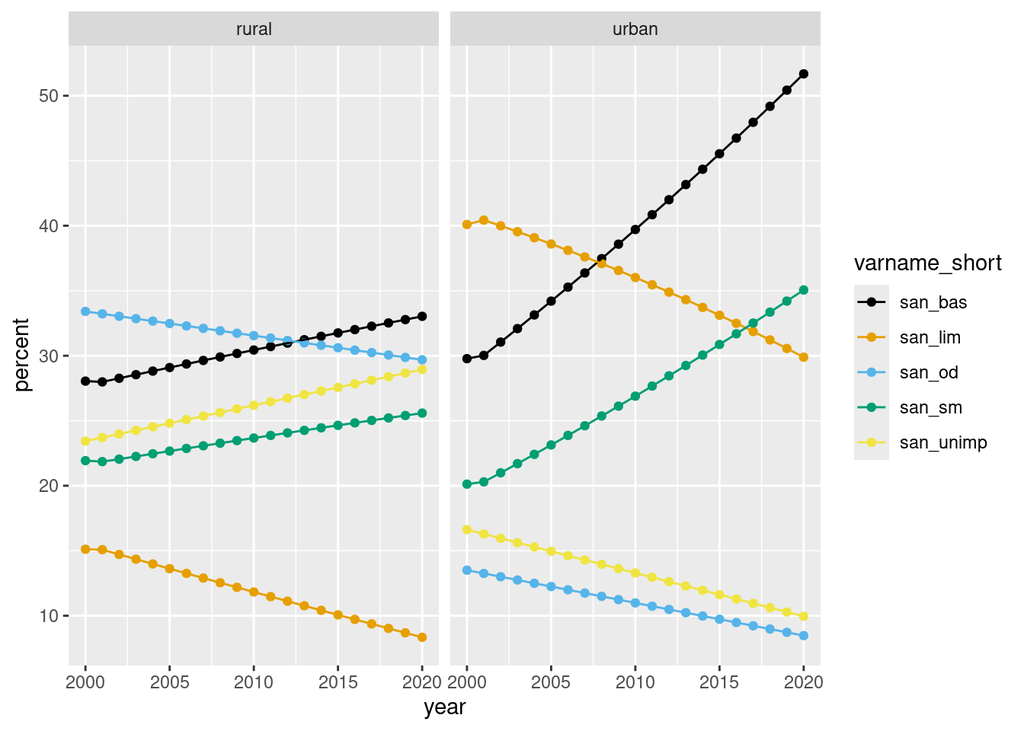

```r
ggplot(data = sanitation_nigeria_urban_rural,
       mapping = aes(x = year,
                     y = percent,
                     group = varname_short,
                     color = varname_short)) +
  geom_point() +
  geom_line() +
  facet_wrap(~residence) +
  scale_color_colorblind()
```

# Module 03c: Summary data transformation

```r
library(readr)
library(dplyr)
```

## Import

In this exercise we use data of the UNICEF/WHO Joint Monitoring Programme (JMP) for Water Supply, Sanitation and Hygiene (WASH). The data is available at https://washdata.org/data and published as an R data package at https://github.com/WASHNote/jmpwashdata/.

The data set `jmp_wld_sanitation_long` is available in the `data` folder of this repository. The data set is in long format and contains the following variables:

- `name`: country name
- `iso3`: ISO3 country code
- `year`: year of observation
- `region_sdg`: SDG region
- `residence`: residence type (national, rural, urban)
- `varname_short`: short variable name (JMP naming convention)
- `varname_long`: long variable name (JMP naming convention)

We use the `read_csv()` function to import the data set into R.

```r
sanitation <- read_csv("data/jmp_wld_sanitation_long.csv")
```

### Task 1.1

1. Run all code chunks above.
2. Use the `glimpse()` function to get an overview of the data set.
3. How many variables are in the data set?

```r
glimpse(sanitation)
```

```
Rows: 73,710
Columns: 8
$ name          <chr> "Afghanistan", "Afghanistan", "Afghanistan", "Afghanista…
$ iso3          <chr> "AFG", "AFG", "AFG", "AFG", "AFG", "AFG", "AFG", "AFG", …
$ year          <dbl> 2000, 2000, 2000, 2000, 2000, 2000, 2000, 2000, 2000, 20…
$ region_sdg    <chr> "Central and Southern Asia", "Central and Southern Asia"…
$ varname_short <chr> "san_bas", "san_bas", "san_bas", "san_lim", "san_lim", "…
$ varname_long  <chr> "basic sanitation services", "basic sanitation services"…
$ residence     <chr> "national", "rural", "urban", "national", "rural", "urba…
$ percent       <dbl> 21.870802, 19.322798, 30.863719, 5.648528, 3.136148, 14.…
```

## Transform

### Task 2.1

1. Use the `count()` function to identify how many SDG regions are included in the data set.
2. How many SDG regions are in the data set?

```r
sanitation |>
  count(region_sdg)
```

```
# A tibble: 8 × 2
  region_sdg                           n
  <chr>                            <int>
1 Australia and New Zealand          630
2 Central and Southern Asia         4410
3 Eastern and South-Eastern Asia    5670
4 Latin America and the Caribbean  15750
5 Northern America and Europe      16695
6 Oceania                           6615
7 Sub-Saharan Africa               16065
8 Western Asia and Northern Africa  7875
```

### Task 2.2

1. Use the `count()` function to identify the levels in the varname_short and varname_long variables.
2. Which indicator in varname_long does san_od refer to?

```r
sanitation |>
  count(varname_short, varname_long)
```

```
# A tibble: 5 × 3
  varname_short varname_long                           n
  <chr>         <chr>                              <int>
1 san_bas       basic sanitation services          14742
2 san_lim       limited sanitation services        14742
3 san_od        no sanitation facilities           14742
4 san_sm        safely managed sanitation services 14742
5 san_unimp     unimproved sanitation facilities   14742
```

### Task 2.3

1. Use the `filter()` function to create a subset from the `sanitation` data containing national estimates for people with “no sanitation facilities” for the year 2020.
2. Store the result as a new object in your environment with the name `sanitation_national_2020_od`.

```r
sanitation_national_2020_od <- sanitation |>
  filter(residence == "national",
         year == 2020,
         varname_short == "san_od")
```

### Task 2.4

1. Use the `sanitation_national_2020_od` data and the `count()` function to identify the number of countries with 0% for the indicator “no sanitation facilities” in 2020.

```r
sanitation_national_2020_od |>
  count(percent)
```

```
# A tibble: 104 × 2
   percent     n
     <dbl> <int>
 1 0          96
 2 0.00670     1
 3 0.0107      1
 4 0.0169      1
 5 0.0317      1
 6 0.0418      1
 7 0.0965      1
 8 0.100       1
 9 0.105       1
10 0.127       1
# ℹ 94 more rows
```

### Task 2.5

1. How many countries in `sanitation_national_2020_od` data had no estimate for “no sanitation facilities” in 2020? Tipp: A country without an estimate has `NA` for the percent variable.

```r
sanitation_national_2020_od |>
  filter(is.na(percent))
```

```
# A tibble: 36 × 8
   name      iso3   year region_sdg varname_short varname_long residence percent
   <chr>     <chr> <dbl> <chr>      <chr>         <chr>        <chr>       <dbl>
 1 Anguilla  AIA    2020 Latin Ame… san_od        no sanitati… national       NA
 2 Antigua … ATG    2020 Latin Ame… san_od        no sanitati… national       NA
 3 Argentina ARG    2020 Latin Ame… san_od        no sanitati… national       NA
 4 Aruba     ABW    2020 Latin Ame… san_od        no sanitati… national       NA
 5 Azerbaij… AZE    2020 Western A… san_od        no sanitati… national       NA
 6 Bahamas   BHS    2020 Latin Ame… san_od        no sanitati… national       NA
 7 Barbados  BRB    2020 Latin Ame… san_od        no sanitati… national       NA
 8 Bosnia a… BIH    2020 Northern … san_od        no sanitati… national       NA
 9 British … VGB    2020 Latin Ame… san_od        no sanitati… national       NA
10 Brunei D… BRN    2020 Eastern a… san_od        no sanitati… national       NA
# ℹ 26 more rows
```

### Task 2.6

1. Use the `sanitation_national_2020_od` data in combination with `group_by()` and `summarise()` functions to calculate the mean, standard deviation and number of countries for the indicator “no sanitation facilities” in 2020.
2. How did you treat the missing values for the percent variable in the calculation?

```r
sanitation_national_2020_od |>
  filter(!is.na(percent)) |>
  group_by(region_sdg) |>
  summarise(
    mean = mean(percent, na.rm = TRUE),
    sd = sd(percent, na.rm = TRUE),
    n = n()
  )
```

```
# A tibble: 8 × 4
  region_sdg                           mean      sd     n
  <chr>                               <dbl>   <dbl> <int>
1 Australia and New Zealand         0        0          2
2 Central and Southern Asia         3.29     5.38      13
3 Eastern and South-Eastern Asia    5.16     6.97      16
4 Latin America and the Caribbean   2.04     3.70      34
5 Northern America and Europe       0.00698  0.0271    48
6 Oceania                           6.80    13.1       16
7 Sub-Saharan Africa               19.4     18.4       47
8 Western Asia and Northern Africa  1.67     5.41      22
```

# Module 04a: Factors

```r
library(ggplot2)
library(dplyr)
library(readr)
library(ggthemes)
```

## Import

```r
waste <- read_csv("data/processed/waste-city-level-sml.csv")
```

## Explore

1. Run all code chunks above.
2. Use the `glimpse()` function to inspect the `waste` object.
3. What does the data cover? Briefly discuss with your room partner.

```r
glimpse(waste)
```

```
Rows: 367
Columns: 6
$ country              <chr> "Afghanistan", "Afghanistan", "Afghanistan", "Afg…
$ city                 <chr> "Jalalabad", "Kandahar", "Mazar-E-Sharif", "Kabul…
$ iso3c                <chr> "AFG", "AFG", "AFG", "AFG", "AFG", "AGO", "ALB", …
$ income_id            <chr> "LIC", "LIC", "LIC", "LIC", "LIC", "LMC", "UMC", …
$ generation_tons_year <dbl> 58914.45, 120971.00, 52368.40, 1989250.00, 91644.…
$ population           <dbl> 326585, 429000, 635250, 3700000, 337000, 4508000,…
```

1. Use the `count()` function for the `waste` object to count the number of rows for each value of the `income_id` variable.
2. What do the four values of the `income_id` variable represent?

```r
waste |>
  count(income_id)
```

```
# A tibble: 4 × 2
  income_id     n
  <chr>     <int>
1 HIC          88
2 LIC          74
3 LMC         124
4 UMC          81
```

## Transform

1. Use the `c()` function to create a vector with the following values: “HIC”, “UMC”, “LMC”, “LIC”.
2. Use the assignment operator (`<-`) to store the resulting vector as a new object called `levels_income`.

```r
levels_income <- c("HIC", "UMC", "LMC", "LIC")
```

1. Use the `mutate()` function to convert the `income_id` variable to a factor variable with the levels specified in the `levels_income` object.
2. Use the assignment operator (`<-`) to store the resulting data as a new object called `waste_lvl`.

```r
waste_lvl <- waste |>
  mutate(income_id = factor(income_id, levels = levels_income))
```

1. Use the `count()` function to verify that the `income_id` variable is now a factor variable with the correct levels.

```r
waste_lvl |>
  count(income_id)
```

```
# A tibble: 4 × 2
  income_id     n
  <fct>     <int>
1 HIC          88
2 UMC          81
3 LMC         124
4 LIC          74
```

1. Starting with `waste_lvl`, use the `mutate()` function to create a new variable called `generation_kg_capita` that contains the `generation_tons_year` variable divided by the `population` variable and multiplied with 1000.
2. Use the assignment operator (`<-`) to store the resulting data as a new object called `waste_capita`.

```r
waste_capita <- waste_lvl |>
  mutate(generation_kg_capita = generation_tons_year / population * 1000)
```

## Visualize

1. Next to the code chunk option `#| eval:` change the value from false to true.
2. Run the code in the code-chunk below to create a boxplot of the `generation_kg_capita` variable by `income_id`.
3. What do you observe? Discuss with your room partner.

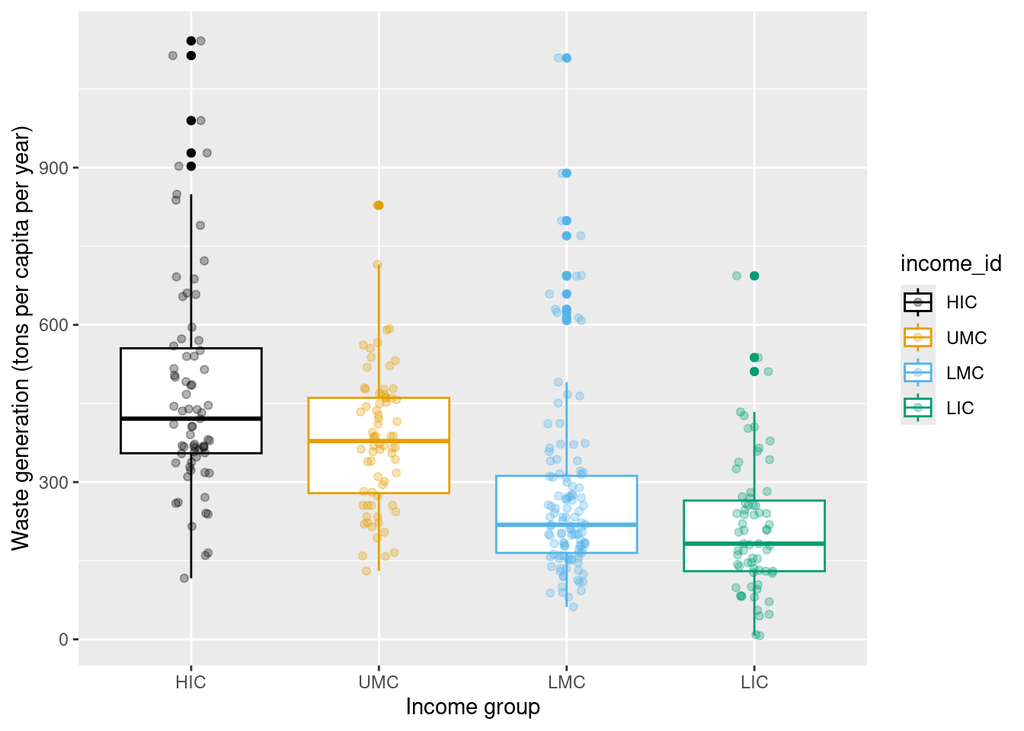

```r
ggplot(data = waste_capita,
       mapping = aes(x = income_id,
                     y = generation_kg_capita,
                     color = income_id)) +
  geom_boxplot(outlier.fill = NA) +
  geom_jitter(width = 0.1, alpha = 0.3) +
  scale_color_colorblind() +
  labs(x = "Income group",
       y = "Waste generation (tons per capita per year)")
```

# Module 04b: Data import

```r
library(readr)
library(readxl)
library(dplyr)
```

## Task 1: Import waste data as CSV

1. Run all code chunks above.
2. Use the `read_csv()` function to import the `waste-city-level.csv` file from the `data/raw` folder.
3. Assign the resulting data to an object called `waste`.

```r
waste <- read_csv("data/raw/waste-city-level.csv")
```

## Task 2: Import JMP data as CSV

1. Use the `read_csv()` function to import the `jmp_wld_sanitation_long.csv` file from the `data/processed` folder.
2. Assign the resulting data to an object called `san_csv`.

```r
san_csv <- read_csv("data/processed/jmp_wld_sanitation_long.csv")
```

## Task 3: Import JMP data as RDS

1. Use the `read_rds()` function to import the `jmp_wld_sanitation_long.rds` file from the `data/processed` folder.
2. Assign the resulting data to an object called `san_rds`.

```r
san_rds <- read_rds("data/processed/jmp_wld_sanitation_long.rds")
```

## Task 4: Compare CSV and RDS

1. Use the `glimpse()` function to inspect the `san_csv` and `san_rds` objects.
2. What is the difference between the two objects? Discuss with your room partner.

```r
glimpse(san_csv)
```

```
Rows: 73,710
Columns: 8
$ name          <chr> "Afghanistan", "Afghanistan", "Afghanistan", "Afghanista…
$ iso3          <chr> "AFG", "AFG", "AFG", "AFG", "AFG", "AFG", "AFG", "AFG", …
$ year          <dbl> 2000, 2000, 2000, 2000, 2000, 2000, 2000, 2000, 2000, 20…
$ region_sdg    <chr> "Central and Southern Asia", "Central and Southern Asia"…
$ varname_short <chr> "san_bas", "san_bas", "san_bas", "san_lim", "san_lim", "…
$ varname_long  <chr> "basic sanitation services", "basic sanitation services"…
$ residence     <chr> "national", "rural", "urban", "national", "rural", "urba…
$ percent       <dbl> 21.870802, 19.322798, 30.863719, 5.648528, 3.136148, 14.…
```

```r
glimpse(san_rds)
```

```
Rows: 73,710
Columns: 8
$ name          <chr> "Afghanistan", "Afghanistan", "Afghanistan", "Afghanista…
$ iso3          <chr> "AFG", "AFG", "AFG", "AFG", "AFG", "AFG", "AFG", "AFG", …
$ year          <dbl> 2000, 2000, 2000, 2000, 2000, 2000, 2000, 2000, 2000, 20…
$ region_sdg    <chr> "Central and Southern Asia", "Central and Southern Asia"…
$ varname_short <fct> san_bas, san_bas, san_bas, san_lim, san_lim, san_lim, sa…
$ varname_long  <fct> basic sanitation services, basic sanitation services, ba…
$ residence     <fct> national, rural, urban, national, rural, urban, national…
$ percent       <dbl> 21.870802, 19.322798, 30.863719, 5.648528, 3.136148, 14.…
```

## Task 5: Use LLM for an explanation

1. Open https://www.perplexity.ai/ in your browser and enter the following prompt:

You are an experienced educator in teaching R to novice users without prior knowledge. Explain what the .rds format is and how it differs from the .csv file format. Avoid technical language.

2. Read the answer and ask the tool questions for clarification of something is unclear.
3. Share a link to your conversation here (see screenshot below):

### Screenshot

[figure not shown]

#Module 05:Conditions

```r
library(tidyverse)
library(ggthemes)
```

## Import

We continue to work with a subset of the “What a Waste” database.

```r
waste <- read_csv("data/processed/waste-city-level-sml.csv")
```

We will also use an example spreadsheet that was created by one of the course participants.

```r
solids <- readxl::read_excel("data/raw/TS_poo_2022.xlsx")
```

## Explore

```r
glimpse(waste)
```

```
Rows: 367
Columns: 6
$ country              <chr> "Afghanistan", "Afghanistan", "Afghanistan", "Afg…
$ city                 <chr> "Jalalabad", "Kandahar", "Mazar-E-Sharif", "Kabul…
$ iso3c                <chr> "AFG", "AFG", "AFG", "AFG", "AFG", "AGO", "ALB", …
$ income_id            <chr> "LIC", "LIC", "LIC", "LIC", "LIC", "LMC", "UMC", …
$ generation_tons_year <dbl> 58914.45, 120971.00, 52368.40, 1989250.00, 91644.…
$ population           <dbl> 326585, 429000, 635250, 3700000, 337000, 4508000,…
```

```r
waste |>
    count(income_id)
```

```
# A tibble: 4 × 2
  income_id     n
  <chr>     <int>
1 HIC          88
2 LIC          74
3 LMC         124
4 UMC          81
```

## Transform

Conditional statements with mutate() & case_when() of dplyr R package

### waste data

```r
waste_cat <- waste |>
    mutate(generation_kg_capita = generation_tons_year / population * 1000) |>
    mutate(income_cat = case_when(
        income_id == "HIC" ~ "high income",
        income_id == "UMC" ~ "upper-middle income",
        income_id == "LMC" ~ "lower-middle income",
        income_id == "LIC" ~ "low income"
    ))


levels_income <- c("HIC", "UMC", "LMC", "LIC")

levels_income_cat <- c("high income",
                       "upper-middle income",
                       "lower-middle income",
                       "low income")

waste_fct <- waste_cat |>
    mutate(income_id = factor(income_id, levels = levels_income)) |>
    mutate(income_cat = factor(income_cat, levels = levels_income_cat)) |>
    relocate(income_cat, .after = income_id)
```

```r
write_rds(x = waste_fct, file = "data/processed/waste-city-level-sml.rds")
```

### Faecal sludge solids data

```r
solids |>
    mutate(total_solids_gL = case_when(
        source_type == "septic tank" ~ total_solids_gL * 100,
        .default = total_solids_gL
    ))
```

```
# A tibble: 20 × 5
   source_location source_type Sample_Date         n_daily_users total_solids_gL
   <chr>           <chr>       <dttm>                      <dbl>           <dbl>
 1 household       pit latrine 2022-11-01 00:00:00             5            20.5
 2 household       pit latrine 2022-11-01 00:00:00             7            25.8
 3 household       pit latrine 2022-11-01 00:00:00             7            22.6
 4 household       pit latrine 2022-11-01 00:00:00             6            30.9
 5 household       pit latrine 2022-11-01 00:00:00             8            48.3
 6 household       septic tank 2022-11-02 00:00:00             9             8
 7 household       septic tank 2022-11-02 00:00:00             6            11
 8 household       septic tank 2022-11-02 00:00:00             7             5
 9 household       septic tank 2022-11-02 00:00:00             7            13
10 household       septic tank 2022-11-02 00:00:00             5             9
11 public toilet   pit latrine 2022-11-03 00:00:00            35            35.0
12 public toilet   pit latrine 2022-11-03 00:00:00            28            29.3
13 public toilet   pit latrine 2022-11-03 00:00:00            52            19.9
14 public toilet   pit latrine 2022-11-03 00:00:00            19            42.4
15 public toilet   pit latrine 2022-11-03 00:00:00            39            28.0
16 public toilet   septic tank 2022-11-04 00:00:00            75             7
17 public toilet   septic tank 2022-11-04 00:00:00            53            14
18 public toilet   septic tank 2022-11-04 00:00:00            47            19
19 public toilet   septic tank 2022-11-04 00:00:00            39             9
20 public toilet   septic tank 2022-11-04 00:00:00            62            11
```

## Visualize

### Categories as character

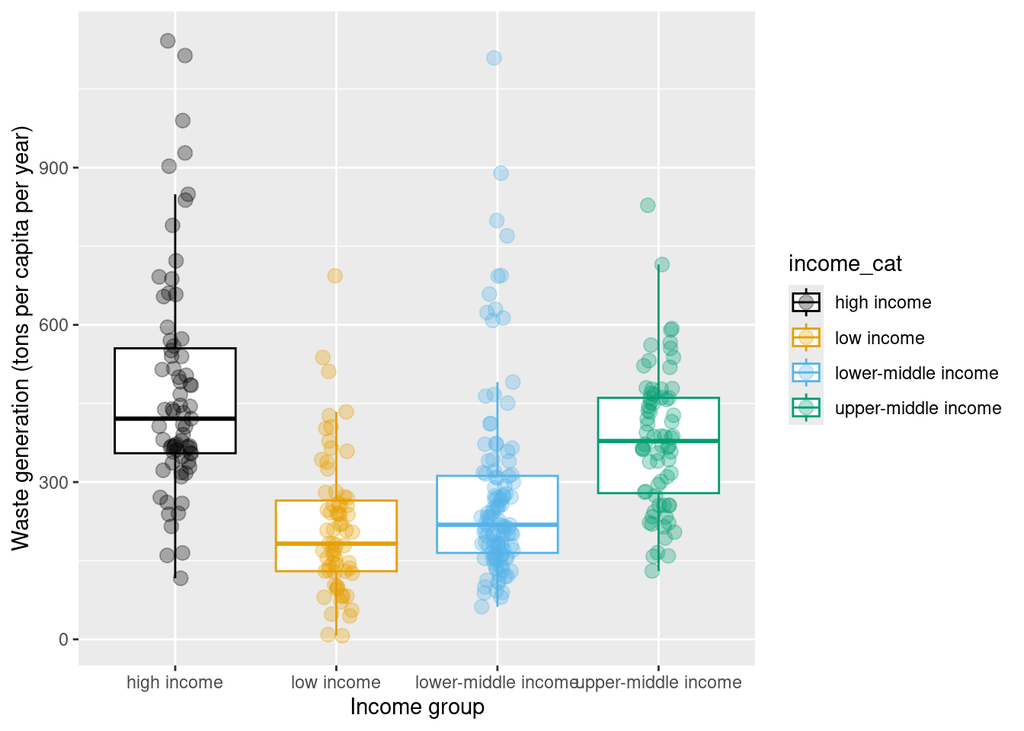

```r
ggplot(data = waste_cat,
       mapping = aes(x = income_cat,
                     y = generation_kg_capita,
                     color = income_cat)) +
    geom_boxplot(outlier.shape = NA) +
    geom_jitter(size = 3, width = 0.1, alpha = 0.3) +
    scale_color_colorblind() +
    labs(x = "Income group",
         y = "Waste generation (tons per capita per year)")
```

### Categories as factor

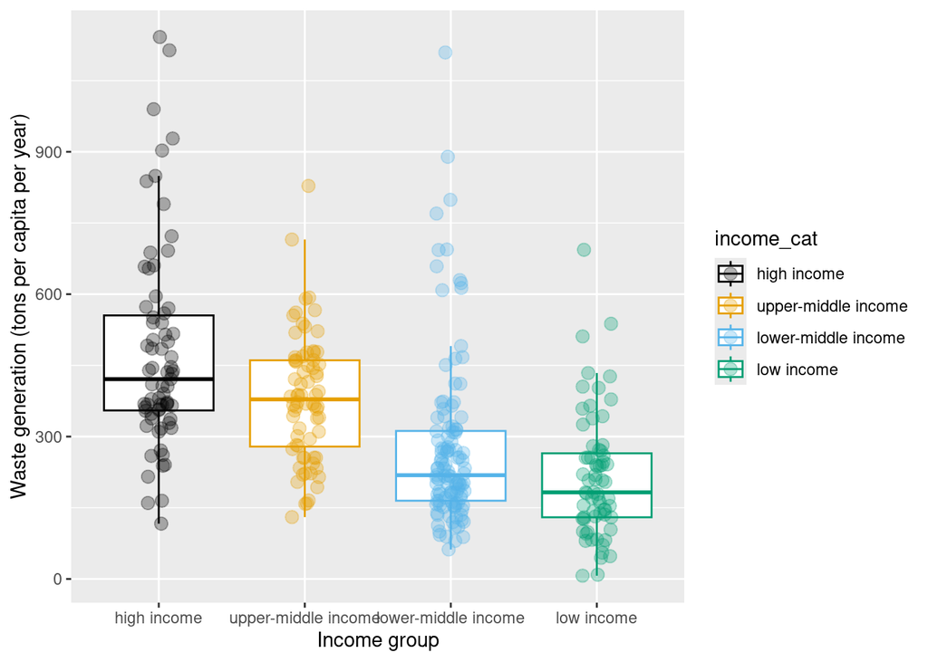

```r
#| eval: true
ggplot(data = waste_fct,
       mapping = aes(x = income_cat,
                     y = generation_kg_capita,
                     color = income_cat)) +
    geom_boxplot(outlier.shape = NA) +
    geom_jitter(size = 3, width = 0.1, alpha = 0.3) +
    scale_color_colorblind() +
    labs(x = "Income group",
         y = "Waste generation (tons per capita per year)")
```

#Module 05a: Mutate()

```r
library(tidyverse)
library(readxl)
```

## Import

We are using another faecal sludge solids example dataset

```r
sludge <- read_xlsx("data/raw/faecal-sludge-analysis.xlsx")
```

## Task 1

1. A mistake happened during data entry for sample id 16. Use `mutate()` and `case_when()` to change the ts value of 0.72 to 8.72.

```r
sludge |>
    mutate(ts = case_when(
        ts ==  0.72 ~ 8.72,
        .default = ts
    ))
```

```
# A tibble: 20 × 6
      id date_sample         system      location      users     ts
   <dbl> <dttm>              <chr>       <chr>         <dbl>  <dbl>
 1     1 2023-11-01 00:00:00 pit latrine household         5 136.
 2     2 2023-11-01 00:00:00 pit latrine household         7 102.
 3     3 2023-11-01 00:00:00 pit latrine household        NA  57.0
 4     4 2023-11-01 00:00:00 pit latrine household         6  27.0
 5     5 2023-11-01 00:00:00 pit latrine household        12  97.3
 6     6 2023-11-02 00:00:00 pit latrine household         7  78.2
 7     7 2023-11-02 00:00:00 septic tank household        14  15.2
 8     8 2023-11-02 00:00:00 septic tank household         4  29.4
 9     9 2023-11-02 00:00:00 septic tank household        10  64.2
10    10 2023-11-02 00:00:00 septic tank household        12   8.01
11    11 2023-11-03 00:00:00 pit latrine public toilet    50  11.2
12    12 2023-11-03 00:00:00 pit latrine public toilet    32  84.0
13    13 2023-11-03 00:00:00 pit latrine public toilet    41  55.9
14    14 2023-11-03 00:00:00 pit latrine public toilet   160  15.3
15    15 2023-11-03 00:00:00 pit latrine public toilet    20  22.6
16    16 2023-11-04 00:00:00 septic tank public toilet    26   8.72
17    17 2023-11-04 00:00:00 septic tank public toilet    91  43.9
18    18 2023-11-04 00:00:00 septic tank public toilet    68  10.4
19    19 2023-11-04 00:00:00 septic tank public toilet   112  23.2
20    20 2023-11-04 00:00:00 septic tank public toilet    59  15.6
```

## Task 2

1. Another mistake happened during data entry for sample id 6. Use `mutate()` and `case_when()` to change the system value of id 6 from “pit latrine” to “septic tank”.

```r
sludge |>
    mutate(system = case_when(
        id ==  6 ~ "septic tank",
        .default = system
    ))
```

```
# A tibble: 20 × 6
      id date_sample         system      location      users     ts
   <dbl> <dttm>              <chr>       <chr>         <dbl>  <dbl>
 1     1 2023-11-01 00:00:00 pit latrine household         5 136.
 2     2 2023-11-01 00:00:00 pit latrine household         7 102.
 3     3 2023-11-01 00:00:00 pit latrine household        NA  57.0
 4     4 2023-11-01 00:00:00 pit latrine household         6  27.0
 5     5 2023-11-01 00:00:00 pit latrine household        12  97.3
 6     6 2023-11-02 00:00:00 septic tank household         7  78.2
 7     7 2023-11-02 00:00:00 septic tank household        14  15.2
 8     8 2023-11-02 00:00:00 septic tank household         4  29.4
 9     9 2023-11-02 00:00:00 septic tank household        10  64.2
10    10 2023-11-02 00:00:00 septic tank household        12   8.01
11    11 2023-11-03 00:00:00 pit latrine public toilet    50  11.2
12    12 2023-11-03 00:00:00 pit latrine public toilet    32  84.0
13    13 2023-11-03 00:00:00 pit latrine public toilet    41  55.9
14    14 2023-11-03 00:00:00 pit latrine public toilet   160  15.3
15    15 2023-11-03 00:00:00 pit latrine public toilet    20  22.6
16    16 2023-11-04 00:00:00 septic tank public toilet    26   0.72
17    17 2023-11-04 00:00:00 septic tank public toilet    91  43.9
18    18 2023-11-04 00:00:00 septic tank public toilet    68  10.4
19    19 2023-11-04 00:00:00 septic tank public toilet   112  23.2
20    20 2023-11-04 00:00:00 septic tank public toilet    59  15.6
```

## Task 3 (stretch goal)

1. Add a new variable with the name `ts_cat` to the data frame that categorizes sludge samples into low, medium and high solids content.Use `mutate()` and `case_when()` to create the new variable.
- samples with less than 15 g/L are categorized as low
- samples with 15 g/L to 50 g/L are categorized as medium
- samples with more than 50 g/L are categorized as high

```r
sludge |>
    mutate(ts_cat = case_when(
        ts < 15 ~ "low",
        ts >= 15 & ts <= 50 ~ "medium",
        ts > 50 ~ "high"
    ))
```

```
# A tibble: 20 × 7
      id date_sample         system      location      users     ts ts_cat
   <dbl> <dttm>              <chr>       <chr>         <dbl>  <dbl> <chr>
 1     1 2023-11-01 00:00:00 pit latrine household         5 136.   high
 2     2 2023-11-01 00:00:00 pit latrine household         7 102.   high
 3     3 2023-11-01 00:00:00 pit latrine household        NA  57.0  high
 4     4 2023-11-01 00:00:00 pit latrine household         6  27.0  medium
 5     5 2023-11-01 00:00:00 pit latrine household        12  97.3  high
 6     6 2023-11-02 00:00:00 pit latrine household         7  78.2  high
 7     7 2023-11-02 00:00:00 septic tank household        14  15.2  medium
 8     8 2023-11-02 00:00:00 septic tank household         4  29.4  medium
 9     9 2023-11-02 00:00:00 septic tank household        10  64.2  high
10    10 2023-11-02 00:00:00 septic tank household        12   8.01 low
11    11 2023-11-03 00:00:00 pit latrine public toilet    50  11.2  low
12    12 2023-11-03 00:00:00 pit latrine public toilet    32  84.0  high
13    13 2023-11-03 00:00:00 pit latrine public toilet    41  55.9  high
14    14 2023-11-03 00:00:00 pit latrine public toilet   160  15.3  medium
15    15 2023-11-03 00:00:00 pit latrine public toilet    20  22.6  medium
16    16 2023-11-04 00:00:00 septic tank public toilet    26   0.72 low
17    17 2023-11-04 00:00:00 septic tank public toilet    91  43.9  medium
18    18 2023-11-04 00:00:00 septic tank public toilet    68  10.4  low
19    19 2023-11-04 00:00:00 septic tank public toilet   112  23.2  medium
20    20 2023-11-04 00:00:00 septic tank public toilet    59  15.6  medium
```

#Module 05b: Dates

```r
library(tidyverse)
library(readxl)
```

## Dates

```r
dates <- read_excel("data/raw/date-formats.xlsx")
```

In R and other programming languages, dates are stored as numbers. The number of days since 1970-01-01 is the ISO 8601 standard.

In Excel, dates are stored as numbers of days since 1900-01-01. In Excel, the date number 1 corresponds to “1900-01-01,” but this system incorrectly considers 1900 as a leap year, which it is not. As a result, to correctly interpret date numbers that originate from systems like Excel, the origin “1899-12-30” is used to account for this discrepancy

```r
dates_class <- dates |>
    mutate(date_iso = as_date(date_iso)) |>
    mutate(date_us = mdy(date_us)) |>
    mutate(date_eu = dmy(date_eu)) |>
    mutate(date_num = as_date(date_num, origin = "1899-12-30")) |>
    mutate(date = as_date(date_time)) |>
    mutate(date_time_tz = with_tz(date_time, tzone = "Africa/Kampala")) |>
    mutate(today = today())

OlsonNames()
```

```
  [1] "Africa/Abidjan"                   "Africa/Accra"
  [3] "Africa/Addis_Ababa"               "Africa/Algiers"
  [5] "Africa/Asmara"                    "Africa/Asmera"
  [7] "Africa/Bamako"                    "Africa/Bangui"
  [9] "Africa/Banjul"                    "Africa/Bissau"
 [11] "Africa/Blantyre"                  "Africa/Brazzaville"
 [13] "Africa/Bujumbura"                 "Africa/Cairo"
 [15] "Africa/Casablanca"                "Africa/Ceuta"
 [17] "Africa/Conakry"                   "Africa/Dakar"
 [19] "Africa/Dar_es_Salaam"             "Africa/Djibouti"
 [21] "Africa/Douala"                    "Africa/El_Aaiun"
 [23] "Africa/Freetown"                  "Africa/Gaborone"
 [25] "Africa/Harare"                    "Africa/Johannesburg"
 [27] "Africa/Juba"                      "Africa/Kampala"
 [29] "Africa/Khartoum"                  "Africa/Kigali"
```

[output cut: 292 more lines]

```r
as.numeric(today())
```

```
[1] 19871
```

```r
as_date(1)
```

```
[1] "1970-01-02"
```

```r
dates_class |>
    select(today) |>
    mutate(year = year(today)) |>
    mutate(month = month(today, label = TRUE, abbr = FALSE, locale = "fr_FR")) |>
    mutate(quarter = quarter(today)) |>
    mutate(week = week(today)) |>
    mutate(day = day(today)) |>
    mutate(day_of_week = wday(today, label = TRUE, abbr = FALSE, locale = "fr_FR")) |>
    mutate(day_of_year = yday(today)) |>
    mutate(week_of_year = week(today))
```

```
# A tibble: 1 × 9
  today       year month quarter  week   day day_of_week day_of_year
  <date>     <dbl> <ord>   <int> <dbl> <int> <ord>             <dbl>
1 2024-05-28  2024 May         2    22    28 Tuesday             149
# ℹ 1 more variable: week_of_year <dbl>
```

#Module 05c: Tables

```r
library(tidyverse)
library(gt)
library(gtsummary)
library(knitr)
library(DT)
```

## Import

We continue to work with a subset of the “What a Waste” database.

```r
waste_gt <- read_rds("data/processed/waste-city-level-sml.rds")
```

## Transform

```r
waste_tbl_income <- waste_gt |>
    filter(!is.na(generation_kg_capita))  |>
    group_by(income_cat) |>
    summarise(
        count = n(),
        mean = mean(generation_kg_capita),
        sd = sd(generation_kg_capita),
        median = median(generation_kg_capita),
        min = min(generation_kg_capita),
        max = max(generation_kg_capita)
    )
```

## Table

```r
waste_tbl_income
```

```
# A tibble: 4 × 7
  income_cat          count  mean    sd median    min   max
  <fct>               <int> <dbl> <dbl>  <dbl>  <dbl> <dbl>
1 high income            71  477.  214.   421. 116.   1142.
2 upper-middle income    72  381.  133.   378. 130.    828.
3 lower-middle income   116  275.  179.   219.  62.1  1109.
4 low income             67  215.  130.   182.   6.86  694.
```

```r
waste_tbl_income |>
    gt() |>
    tab_header(title = "Waste generation per capita (kg/year) by income group",
               subtitle = "Data from 326 cities") |>
    fmt_number(columns = count:max, decimals = 0) |>
    cols_label(income_cat = "income category")
```

Waste generation per capita (kg/year) by income group

Data from 326 cities

| income category | count | mean | sd | median | min | max |
| --- | --- | --- | --- | --- | --- | --- |
| high income | 71 | 477 | 214 | 421 | 116 | 1,142 |
| upper-middle income | 72 | 381 | 133 | 378 | 130 | 828 |
| lower-middle income | 116 | 275 | 179 | 219 | 62 | 1,109 |
| low income | 67 | 215 | 130 | 182 | 7 | 694 |

Table 1 highlights that cities in countries classfied as high income countries generate more waste per capita than cities in lower income countries.

```r
waste_tbl_income |>
    rename(`income category` = income_cat) |>
    kable(digits = 0)
```

Table 1: Waste generation per capita (kg/year) by income group. Data from 326 cities.

| income category | count | mean | sd | median | min | max |
| --- | --- | --- | --- | --- | --- | --- |
| high income | 71 | 477 | 214 | 421 | 116 | 1142 |
| upper-middle income | 72 | 381 | 133 | 378 | 130 | 828 |
| lower-middle income | 116 | 275 | 179 | 219 | 62 | 1109 |
| low income | 67 | 215 | 130 | 182 | 7 | 694 |

# Module 06a: Cross-references

## Tables and Figures

```r
library(tidyverse)
library(ggthemes)
library(palmerpenguins)
library(gt)
```

### Task 1: Tables

1. Render the document and identify if the cross-reference to the table generated from the code below works.
2. Fix the label in the code-chunk below so that the cross-reference works.
3. Render the document to check if the cross-reference to the table generated from the code below works

See Table 2 for data on a few penguins.

```r
penguins |>
  filter(!is.na(bill_depth_mm)) |>
  group_by(island, species) |>
  summarise(n = n(),
            mean_bill_depth = mean(bill_depth_mm),
            sd_bill_depth = sd(bill_depth_mm)) |>
  ungroup() |>
  gt() |>
  fmt_number(columns = c(mean_bill_depth, sd_bill_depth),
             decimals = 1)
```

Table 2: Bill depth of penquins by island and species.

| island | species | n | mean_bill_depth | sd_bill_depth |
| --- | --- | --- | --- | --- |
| Biscoe | Adelie | 44 | 18.4 | 1.2 |
| Biscoe | Gentoo | 123 | 15.0 | 1.0 |
| Dream | Adelie | 56 | 18.3 | 1.1 |
| Dream | Chinstrap | 68 | 18.4 | 1.1 |
| Torgersen | Adelie | 51 | 18.4 | 1.3 |

### Task 2: Figures

1. Add a caption and a label for a figure to the code chunk options below.
2. Add a cross-reference to the figure generated from the code below.

In Figure 1, we see that …

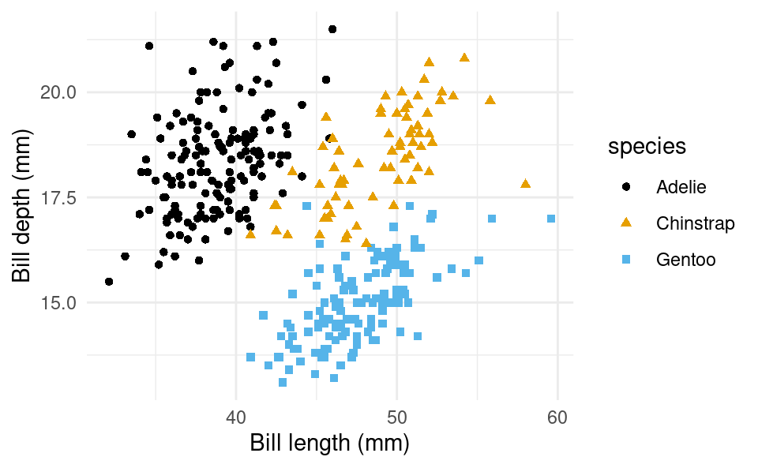

Figure 1: Bill length and depth of penguins

```r
ggplot(data = penguins,
       mapping = aes(x = bill_length_mm,
                     y = bill_depth_mm,
                     color = species,
                     shape = species)) +
  geom_point() +
  scale_color_colorblind() +
  labs(x = "Bill length (mm)", y = "Bill depth (mm)") +
  theme_minimal()
```

#Module 06b: Vector types”

```r
library(tidyverse)
library(gapminder)
```

## Part 1: (Atomic) Vectors

Atomic vectors, of which there are six types: logical, integer, double, character, complex, and raw.

Integer and double vectors are collectively known as numeric vectors.

- lgl: logical
- int: integer
- dbl: double
- chr: character

```r
glimpse(gapminder)
```

```
Rows: 1,704
Columns: 6
$ country   <fct> "Afghanistan", "Afghanistan", "Afghanistan", "Afghanistan", …
$ continent <fct> Asia, Asia, Asia, Asia, Asia, Asia, Asia, Asia, Asia, Asia, …
$ year      <int> 1952, 1957, 1962, 1967, 1972, 1977, 1982, 1987, 1992, 1997, …
$ lifeExp   <dbl> 28.801, 30.332, 31.997, 34.020, 36.088, 38.438, 39.854, 40.8…
$ pop       <int> 8425333, 9240934, 10267083, 11537966, 13079460, 14880372, 12…
$ gdpPercap <dbl> 779.4453, 820.8530, 853.1007, 836.1971, 739.9811, 786.1134, …
```

### Types of atomic vectors

```r
vector_lgl <- c(TRUE, TRUE, FALSE)
typeof(vector_lgl)
```

```
[1] "logical"
```

```r
sum(vector_lgl)
```

```
[1] 2
```

```r
as.numeric(vector_lgl)
```

```
[1] 1 1 0
```

```r
vector_int <- c(1L, 3L, 6L)
typeof(vector_int)
```

```
[1] "integer"
```

```r
vector_dbl <- c(1293, 5.1, 90.5)
typeof(vector_dbl)
```

```
[1] "double"
```

```r
vector_chr <- c("large", "small", "medium")
typeof(vector_chr)
```

```
[1] "character"
```

### Logical vectors

```r
vector_dbl > 150
```

```
[1]  TRUE FALSE FALSE
```

```r
"large" == vector_chr
```

```
[1]  TRUE FALSE FALSE
```

```r
str_detect(vector_chr, "lar")
```

```
[1]  TRUE FALSE FALSE
```

### Explicit vector coercion & augmented vectors

Vectors can also contain arbitrary additional metadata in the form of attributes. These attributes are used to create augmented vectors which build on additional behavior. For example, factors are built on top of integer vectors.

```r
vector_fct <- factor(vector_chr, levels = c("small", "medium", "large"))

typeof(vector_fct)
```

```
[1] "integer"
```

```r
attributes(vector_fct)
```

```
$levels
[1] "small"  "medium" "large"

$class
[1] "factor"
```

```r
as.integer(vector_fct)
```

```
[1] 3 1 2
```

### Tibbles / Dataframes

Tibbles / dataframes have vectors as columns. Each vector has the same length. Each vector can be thought of as a column and the length of each vector is the number of rows.

```r
tib_data <- tibble(
  vector_lgl,
  vector_int,
  vector_dbl,
  vector_chr,
  vector_fct,
  date = Sys.Date()
)
```

### Accessing a vector from a dataframe

```r
tib_data |>
  pull(vector_fct)
```

```
[1] large  small  medium
Levels: small medium large
```

```r
tib_data$vector_fct
```

```
[1] large  small  medium
Levels: small medium large
```

```r
tib_data[5]
```

```
# A tibble: 3 × 1
  vector_fct
  <fct>
1 large
2 small
3 medium
```

```r
tib_data[[5]]
```

```
[1] large  small  medium
Levels: small medium large
```